# 演習の模範解答

プログラミング演習Ⅱ

佐藤 秀保

sato0035@toyo.jp

## 第14回演習１

- 10月，11月，12月の売上の分布を比較するヒストグラムを作成せよ
  - 色，パターン，透明度など自由にカスタマイズ
  - 違いはある？：中心の位置，バラツキ
- ただし，以下の実行を前提とする．

```python
#---データのアップロード---
from google.colab import files
uploaded = files.upload()
#---
#データ読込
import pandas as pd
df = pd.read_csv("s2025_aki_clean.csv")
```

## 第14回演習２

- 10月，11月，12月の売上の分布を比較する箱ひげ図を作成せよ
  - 色，jitterなど自由にカスタマイズ
- ただし，第14回演習１の前提としているコードは実行済みとする．

## 第13回演習１

- 縦軸を`n_customers`（客数）に変更して，自由に折れ線グラフを作成
- ただし，以下の実行を前提とする．

```python
#---データのアップロード---
from google.colab import files
uploaded = files.upload()
#---
#データ読込
import pandas as pd
df = pd.read_csv("s2025_aki.csv")
#列名変更
df1 = df.rename(columns={"日付":"date",
                        "純売上":"sales",
                        "客数":"n_customers"}
                )
#3列のみ抽出
df1 = df1[["date", "sales", "n_customers"]]
#dateを文字型から日付型に
df1["date"] = pd.to_datetime(df1["date"])
#曜日列を作成（3文字）
df1["weekday"] = df1["date"].dt.strftime("%a")
#dateで並び替え
df1 = df1.sort_values("date")
#欠損のある行削除
df1 = df1.dropna(subset=["sales", "n_customers"])
```

### 解答例

```python
plt.plot(
    df1["date"],
    df1["n_customers"],
    color="tab:green",#色
    linestyle="--",#線のスタイル
    linewidth=2,#線の太さ
    marker="+" #データの点
)
plt.show()
```

## 第13回演習２

- 縦軸を`n_customers`（客数）に変更して，客数平均の曜日別棒グラフを自由に作成

※ヒント：グループ別平均のデータから作成を始める

- ただし，第13回演習１の前提としているコードは実行済みとする．

### 解答例

```python
#曜日別平均客数のデータ
df_group = df1.groupby("weekday",as_index=False)["n_customers"].mean()
#棒グラフ
plt.bar(df_group["weekday"], df_group["n_customers"])
plt.show()
```

```python
#参考：横軸の曜日を月曜から順にしたい場合は以下
order = ["Mon", "Tue", "Wed", "Thu", "Fri", "Sat", "Sun"]
df_group = df1.groupby("weekday",as_index=False)["n_customers"].mean()
df_group["weekday"] = pd.Categorical(
    df_group["weekday"],
    categories=order,
    ordered=True
)
df_group = df_group.sort_values("weekday")
plt.bar(df_group["weekday"], df_group["n_customers"])
plt.show()
```

## 第11回演習

- 11月24日（月）は勤労感謝の日振り替え休日なのに授業実施日だったので，食堂利用者が平時より少なかったかもしれない．
- 12月1日（月）～5日（金）のデータを用いて今日の内容と全く同じことを行い，曜日別の販売点数に同様の傾向があるかを確認するコードを書くこと．

## 第11回演習（つづき）

- 授業コードは以下

```python
#---データのアップロード---
#実行後，Shiftを押しながらファイルのクリックで５ファイルをまとめて選択
from google.colab import files
uploaded = files.upload()
#---
import pandas as pd
df_mon = pd.read_csv("s20251124.csv")#月
df_tue = pd.read_csv("s20251125.csv")#火
df_wed = pd.read_csv("s20251126.csv")#水
df_thu = pd.read_csv("s20251127.csv")#木
df_fri = pd.read_csv("s20251128.csv")#金

#1.列の追加
df_mon["day"] = "Mon"
df_tue["day"] = "Tue"
df_wed["day"] = "Wed"
df_thu["day"] = "Thu"
df_fri["day"] = "Fri"

#2.データ結合（行）
df = pd.concat(
  [df_mon, df_tue, df_wed, df_thu, df_fri],
  axis=0,
  ignore_index=True
)

#3.列の抽出
df_quantity = df[["day", "販売点数"]]

#4.列名の変更
df_quantity = df_quantity.rename(columns={"販売点数":"quantity"})

#5.集計（グループ別）
df_group = df_quantity.groupby("day",as_index=False)["quantity"].sum()

#6.行の並び替え（降順）
df_group = df_group.sort_values("quantity",ascending=False)

print(df_group)
```

### 解答例

```python
#---データのアップロード---
#実行後，Shiftを押しながらファイルのクリックで５ファイルをまとめて選択
from google.colab import files
uploaded = files.upload()
#---
import pandas as pd
df_mon = pd.read_csv("s20251201.csv")#月
df_tue = pd.read_csv("s20251202.csv")#火
df_wed = pd.read_csv("s20251203.csv")#水
df_thu = pd.read_csv("s20251204.csv")#木
df_fri = pd.read_csv("s20251205.csv")#金

#1.列の追加
df_mon["day"] = "Mon"
df_tue["day"] = "Tue"
df_wed["day"] = "Wed"
df_thu["day"] = "Thu"
df_fri["day"] = "Fri"

#2.データ結合（行）
df = pd.concat(
  [df_mon, df_tue, df_wed, df_thu, df_fri],
  axis=0,
  ignore_index=True
)

#3.列の抽出
df_quantity = df[["day", "販売点数"]]

#4.列名の変更
df_quantity = df_quantity.rename(columns={"販売点数":"quantity"})

#5.集計（グループ別）
df_group = df_quantity.groupby("day",as_index=False)["quantity"].sum()

#6.行の並び替え（降順）
df_group = df_group.sort_values("quantity",ascending=False)

print(df_group)
```

### 解答例（つづき）

- 左が11月，右が12月

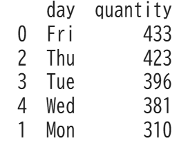

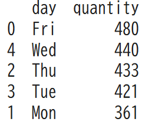

- 販売点数のトップは金曜で11月，12月で変わらず
- ワーストも月曜で11月，12月で変わらず
  - しかし11月の方が少なく祝日効果があったかもしれない

## 第10回演習１

- 商品名のリスト`list_names`，
- 売上価格のリスト`list_prices`，
- 売上数量のリスト`list_quantities`

を列とする`pandas.DataFrame`「`df_uriage`」を生成し`print`関数で表示せよ．

- ただし，以下のコードを読み込み，列名はそれぞれ`product_names`，`prices`，`quantities` とする．